# Lab 4 - In class exercise - Answers

Luis Navarro

1. Import the fastfood data set explored in class. Load the packages dplyr, ggplot2, and descriptr

```r
# Clean the environment
rm(list=ls())

# Set your working directory
setwd("/Users/luisenriquenavarro/Library/CloudStorage/OneDrive-IndianaUniversity/V506/Fall24/Lab4")

# New Packages
if(!require(descriptr)){install.packages("descriptr")}

# Packages Required for the session
library(pacman)
p_load(dplyr, ggplot2, rmarkdown,
       descriptr,
       rio, here)

# Load fast food
fastfood <- rio::import(file = "fastfood.csv", header = TRUE) %>% tibble()
```

2. Following the code covered in class, write a function that takes as input a vector of data (say a variable from a data frame) The function should compute the mean, standard deviation, variance, and median of such variable. The output of the function should be a data frame with 4 columns: Mean, Median, SD, and Variance.

There are two potential answers for this. Using base R and summarize from dplyr.

```r
# Base R
descriptive_stats <- function(data){

  # Compute the Descriptive Statistics using base R functions
  mean <- mean(data, na.rm = TRUE)
  median <- median(data, na.rm = TRUE)
  sd <- sd(data, na.rm = TRUE)
  var <- var(data, na.rm = TRUE)

  # Save output as data frame (tibble object)
  # note: I capitalize the variable names just to avoid confusion with the objects defined inside the function.
  # you can assign them the same name as the objects and it works fine
  table <- tibble(
    Mean = mean,
    Median = median,
    SD = sd,
    VAR = var
    )

  # Return Table
  return(table)
}
```

```r
# test the function
descriptive_stats(
  data = fastfood$calories
  )
```

| Mean | Median | SD | VAR |
| --- | --- | --- | --- |
| 530.9126 | 490 | 282.4361 | 79770.18 |

```r
NA
```

```r
# solution 2: using summarize from dplyr
desc_table2 <- function(data){
  # the key difference here is that data is not a vector, but a data frame
  # verify the data used as input is a data frame object (tibble).
  df <- tibble(variable = data)
  # create the table with desc stats
  table <- df %>%
    summarize(
      Mean = mean(variable, na.rm = TRUE),
      Median = median(variable, na.rm = TRUE),
      SD = sd(variable, na.rm = TRUE),
      VAR = var(variable, na.rm = TRUE)
    )

  return(table)
}
```

```r
# test the function
desc_table2(
  data = fastfood$calories
)
```

| Mean | Median | SD | VAR |
| --- | --- | --- | --- |
| 530.9126 | 490 | 282.4361 | 79770.18 |

```r
NA
```

3. Use your user written function to obtain the descriptive statistics of the variables: i) calories, ii) cholesterol, iii) sodium, and iv) sugar

| Mean | Median | SD | VAR |
| --- | --- | --- | --- |
| 530.912621 | 490 | 282.436147 | 79770.1772 |
| 72.456311 | 60 | 63.160406 | 3989.2369 |
| 1246.737864 | 1110 | 689.954278 | 476036.9059 |
| 7.262136 | 6 | 6.761301 | 45.7152 |

5. Use the function ds_summary_stats() from descriptr to compute the descriptive statistics of this new data frame. Compare the results with the output of your user written function.

```r
descriptr::ds_summary_stats(fastfood %>% select(calories, cholesterol, sodium, sugar))
```

```
------------------------------------------------------- Variable: calories -------------------------------------------------------

                            Univariate Analysis

 N                          515.00      Variance                 79770.18
 Missing                      0.00      Std Deviation              282.44
 Mean                       530.91      Range                     2410.00
 Median                     490.00      Interquartile Range        360.00
 Mode                       350.00      Uncorrected SS       186164000.00
 Trimmed Mean               512.13      Corrected SS          41001871.07
 Skewness                     1.41      Coeff Variation             53.20
 Kurtosis                     4.72      Std Error Mean              12.45

                                  Quantiles

                Quantile                                Value

               Max                                     2430.00
               99%                                     1340.20
               95%                                     1033.00
               90%                                      886.00
               Q3                                       690.00
               Median                                   490.00
               Q1                                       330.00
               10%                                      210.00
               5%                                       170.00
               1%                                       110.00
               Min                                      20.00

                                Extreme Values

                  Low                                    High

  Obs                            Value       Obs                            Value
  303                             20         40                             2430
  393                             50         45                             1770
  73                              70         48                             1600
  188                             70         193                            1550
  128                             100        39                             1510

```

[output cut: 110 more lines]

```
             10%                                   1.00
             5%                                    0.70
             1%                                    0.00
             Min                                   0.00

                            Extreme Values

                Low                                High

  Obs                        Value       Obs                        Value
  35                           0         48                          87
  41                           0         47                          52
  42                           0         230                         37
  43                           0         352                         36
  44                           0         46                          35
```

5. Create a box plot for the distribution of calories on the fast food items across restaturants. On the x-axis show the distribution of “calories” and on the y-axis represent the restaurant. Use appropriate labels, coloring, and other graphics best practices.

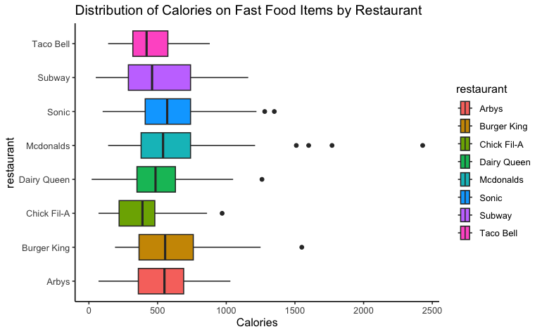

```r
boxplot_calories <- fastfood %>%
  ggplot(mapping = aes(x = calories, y = restaurant,
                       fill = restaurant)) +
  geom_boxplot() +
  labs(x = "Calories",
       title = "Distribution of Calories on Fast Food Items by Restaurant") +
  theme_classic()

boxplot_calories
```

6. Create a scatter plot that shows the correlation between sugar (x-axis) and protein (y-axis) by restaurants on the same panel. Add a specific color for the observations of each restaurant. Use appropriate labels, coloring, and other graphics best practices. Save this graph in your environment. Hint: where in the aesthetic mapping should you specify that the graph will vary across restaurants?

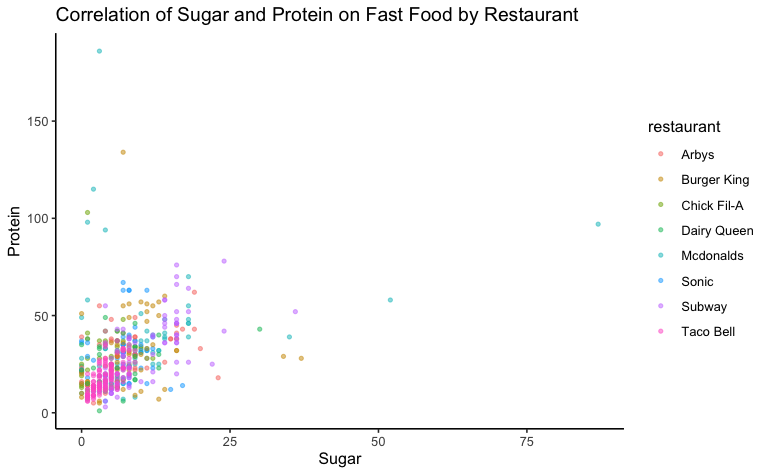

```r
scatter_sugar_protein <- fastfood %>%
  ggplot(mapping = aes(x = sugar, y = protein,
                       color = restaurant)) +
  geom_point(size = 1, alpha = 0.5) +
  labs(x = "Sugar", y = "Protein",
       title = "Correlation of Sugar and Protein on Fast Food by Restaurant")+
  theme_classic()

scatter_sugar_protein
```

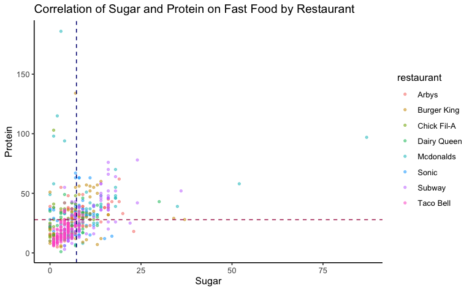

```r
mean_sugar <- fastfood$sugar %>% mean(na.rm = TRUE)
mean_protein <- fastfood$protein %>% mean(na.rm = TRUE)

scatter_sugar_protein_improved <- scatter_sugar_protein +
  geom_vline(xintercept = mean_sugar, color = "navy", linetype = "dashed") +
  geom_hline(yintercept = mean_protein, color = "maroon", linetype = "dashed")

scatter_sugar_protein_improved
```

10. Export this graph using ggsave into your folder.

```r
ggsave(filename = "scatter_protein_sugar.jpg",
       plot = scatter_sugar_protein_improved)
```